# Report - Recommendations to Call Center

Data Detectives

2024-10-28

### Introduction:

This report addresses the current financial challenges faced by the Call Center and explores potential opportunities through data-driven solutions. As previously highlighted by Susan Kim and acknowledged by the entire firm, the business is currently experiencing financial losses. This report will outline possible strategies for the firm to achieve break-even or profitability, leveraging data collected over the recent period.

Given the diverse audience for this report—comprising both business and data specialists—some sections will include technical documentation. However, these technical details are structured to ensure that the primary business goals and opportunities remain clear and accessible at each stage, leading to actionable financial and business recommendations.

For data specialists or enthusiasts, the entire report is recommended reading. For those with a business focus who are primarily interested in results and recommendations, please refer to sections marked with a “**Business Note:**” for concise insights and strategic guidance.

#### a. Getting and Cleaning the Data:

As mentioned, this report aims to understand the current situation of the call center, measure their losses, and find opportunities for it to break even, or even maybe profit. Before staring with the analysis of the current situation and the break even calculation, we need to get the data and clean it. For organizations sake, all the libraries were called in this first snippet, just so they are not lost or repeated in different parts of the code.

```r
# All Libraries used in this file:
library(ggplot2)
library(dplyr)
library(factoextra)
library(smotefamily)
library(randomForest)
library(tidyr)
library(caret)
library(neuralnet)
library(class)
```

Before we start with any calculation, it is important to get the data we will be working with. The following code demonstrates how to do so. By using the `stringAsFactors = T` function, the data variables will be read as factors, avoiding a manual transformation of each, as we will need data as factors on further steps of this report.

```r
tele_data <- read.csv("tele.csv", stringsAsFactors = T)
```

As aforementioned above, we would like to care of our data prior to calculations; in particular, cleaning our data. Doing this now will aid in our analysis, as we don’t want any unnecessary columns or improper data disrupting our analysis.

**Removing unnecessary columns:**

There are two columns in particular we would like to remove from our dataset; `X` and `duration`. `X` is just the row count, and is not pertinent to us at all. `duration` is a post call variable, collected only after a call has been made. If our goal is to predict future successful calls, a post call variable is invalid to use, and will thus be removed; how can we use a variable recorded after a call prior to one being made?

```r
tele_data$X <- NULL
tele_data$duration <- NULL
```

**Pdays column:**

Another column to clean is `pdays`: the number of days that passed by after the client was last contacted from a previous campaign. Looking at the distribution of values the column takes, the vast majority of observations have a value of 999, around 96% to be exact. In this case, 999 represents a client that has never been contacted before. Because of the distribution and the nature of the column, we converted it into a binary variable, 0 if a client hasn’t been contacted before and 1 if they have been; this will make the column better formatted to use in our analysis and easier to interpret. We don’t believe we will loose predictive power by not knowing the time passed from the previous call from around 3% of the data set.

```r
table(tele_data$pdays)
```

```
##
##     0     1     2     3     4     5     6     7     8     9    10    11    12
##    15    26    61   439   118    46   412    60    18    64    52    28    58
##    13    14    15    16    17    18    19    20    21    22    25    26    27
##    36    20    24    11     8     7     3     1     2     3     1     1     1
##   999
## 39673
```

```r
called <- sum(ifelse(tele_data$pdays < 999, 1,0))
never_called <- sum(length(tele_data$pdays))
called_ratio <- (called / (called + never_called))*100
print(paste('The percentage of clients called in this variable is ', round(called_ratio,2),'% of the total database'))
```

```
## [1] "The percentage of clients called in this variable is  3.55 % of the total database"
```

```r
tele_data$pdays <- ifelse(tele_data$pdays == 999, 0, 1)
```

**Encoding:**

We now convert the original dataset into one that represents each factor/level within a column into it’s own separate column (dummies/one-hot encoding). For example, marital turns into maritalunknown, maritalsingle, etc. However, one thing to note is that the model matrix line drops one of the columns for each factor, as to avoid multicolinearity; this was not the case for the job column. Likely due to the inconsistent formatting of the name of the levels of that variable, our model.matrix line wouldn’t drop a column, so we manually dropped one. Additionally, the function changed the name of you dependent variable to `yyes`, so we converted back to `y`. This is just a formality to keep the name consistent through all the report.

```r
encoded_data <- as.data.frame(model.matrix(~ . -1, tele_data))
encoded_data$jobunknown <- NULL
encoded_data$y <- encoded_data$yyes
encoded_data$yyes <- NULL
```

**Scaling Numerical Variables:**

Finally, the last step of cleaning is scaling our data. Further on in our analysis, we will build a KNN and ANN model; for these models, our numeric factors have to be comparable to one another. For this to happen, they have to be on the same scale, so we create a separate variable that contains scaled data for the those models. We utilize min max scaling in this instance, so each numeric variable is now on a scale of 0-1.

```r
minmax <- function(x) {
  (x - min(x)) / (max(x)-min(x))
}
scaled_data <- as.data.frame(lapply(encoded_data, minmax))
```

We have now cleaned our data; removed columns of disinterest, converted some columns to binary scaling, scaled our data and converted factors into columns. We are now ready to move on with our analysis.

### Descriptive Analysis, Data Visualization and Storytelling:

Before trying to find potential solutions, we first want to understand the problem we are trying to solve and understand our data. We will do this with a few calculations and visualizations.

#### a. Current Scenario

We were given some financial details about the call center at the start of the case; using this information, we calculate the current financial state of the company given the data.

```r
successful_calls <- sum(tele_data$y == "yes")
total_calls <- nrow(tele_data)
success_rate <- successful_calls / total_calls

# Define the financial parameters - given by MK - to calculate the BEP
training_cost <- 1000
variable_cost_per_call <- 1
contribution_margin <- 10
avg_retention <- 1000

total_var_cost <- (total_calls*variable_cost_per_call) +
                  ((total_calls/avg_retention)*training_cost)

revenue_per_call <- (total_var_cost/total_calls) + contribution_margin
total_revenue <- (success_rate*total_calls) * revenue_per_call

break_even_revenue <- (total_var_cost)/(contribution_margin)
gross_margin <- total_revenue - total_var_cost
```

**Business Note:** Interesting insights we can gather from a simple data analysis are the following:

1. The current success rate from calls is **11.2654171%**, which means that out of the 41188 only 4640 are successful. As already known by the entire staff, this is very low.
2. Since there are no major fixed costs to account for - as mentioned by MK - we can only calculate the break-even revenue (no fixed costs to deduct). This tells us how much total revenue the company needs to generate to cover their variable costs. The current break-even revenue for the call center is $8237.6.
3. Currently, the call center’s gross margin is **$ -26696**. This just confirms what everyone already knew, that the call center is losing money.

In order to solve this problem, instead of simply increasing the number of total calls, and hoping to increase the total number of successful calls with it, the more efficient solution is to focus on increasing the success rate to be able to break even, or even profit, at the current level of sales. With that in mind, the first question to answer is by how much would the success rate would have to increase for them to break even?

In order to answer this question, there is an important detail to take into account. Besides just considering the current variable costs the company has, and the contribution margin per call, we have to remember MK’s insight that: “every 1% increase in call success rate increased the average retention rate by 100 calls.”

Getting back to the technical content, we built the following function to determine what the break-even success rate should be; what portion of calls needed to be successful for the company to break-even at the current number of total calls. This calculation also factors in the increment in average retention rate with a 1% increase in success rate. While revenue is less than cost (or profit < 0), the function still runs, incrementing the success rate by 1% and retention by 100, than recalculating until we break even. We than get as the return the success rate upon completion of the while loop.

```r
find_success_rate <- function(total_calls, contribution_margin, total_var_cost,  variable_cost_per_call, avg_retention, training_cost, success_rate) {

  while (((success_rate * total_calls)*(contribution_margin+variable_cost_per_call))-total_var_cost < 0) {
    success_rate <- success_rate + 0.01 # increment success rate by 1%
    avg_retention <- avg_retention+100
    total_var_cost <- (total_calls*variable_cost_per_call) +
                  ((total_calls/(avg_retention))*training_cost) # adjust effective calls
  }

  return(success_rate)
}

necessary_success_rate <- find_success_rate(total_calls, contribution_margin, total_var_cost,  variable_cost_per_call, avg_retention, training_cost, success_rate)
```

**Business Note:** The success rate needed to break-even at the current level of total calls it **16.2654171%**, which represent a 5 % increase from the current success rate. This imply a total of 6699.4 successful calls per month.

Now, to conclude this first part of the analytics and visualizations, we are going to display some graphics that will help with a better understanding of the problem, and potential opportunities of solution.

From Figure 1, displayed below, we can simple compare the current success rate with the necessary one.

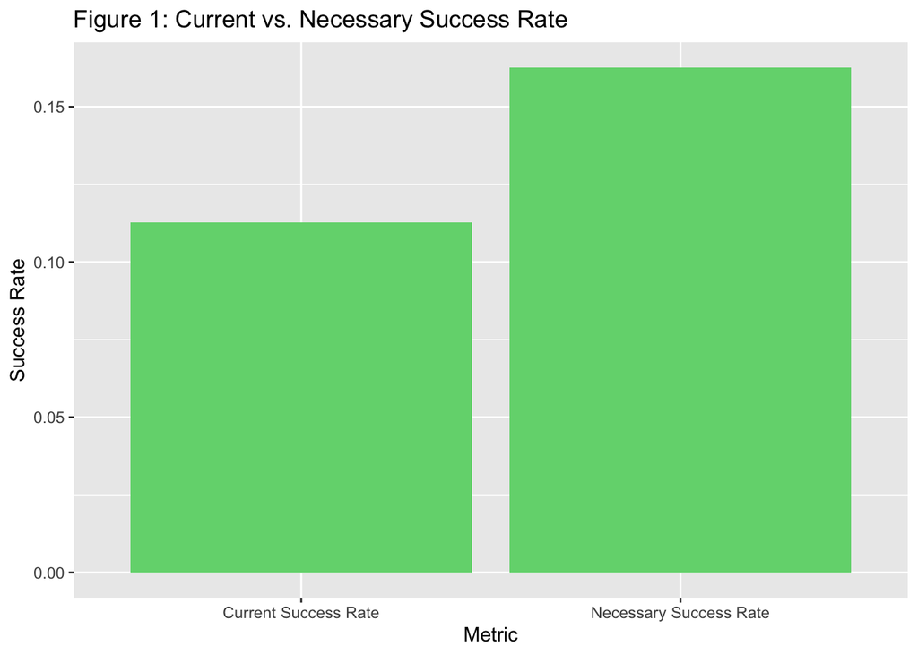

**Business Note:** Although from this graphic it may seem like there is a need for a huge improvement, when looking at the overall numbers, we can see that is a relative small improvement if looking at the total amount of calls. Look for the green increase from left to right on Figure 2.

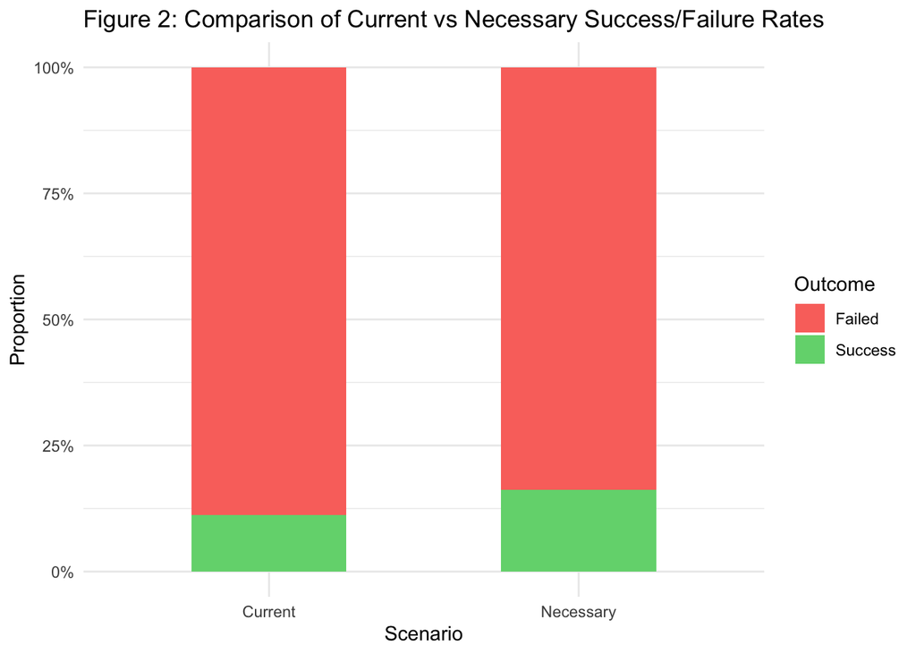

**Business Note:** This figure is similar to figure 1, except now we show the successes in relation to failures in both the current and necessary success rate. This further illustrates how small the improvement has to be in order for the call center to turn things around.

Once we have outlined the overall objective to break even. It is important to understand how to reach that goal. How can the call center increase the success rate? The answer can seem quite simple, by focusing the calls on the people that are most likely to subscribe to the term deposit. To facilitate the visualization, let’s look at how the behavior of customers change in some of the variables offered by the dataset.

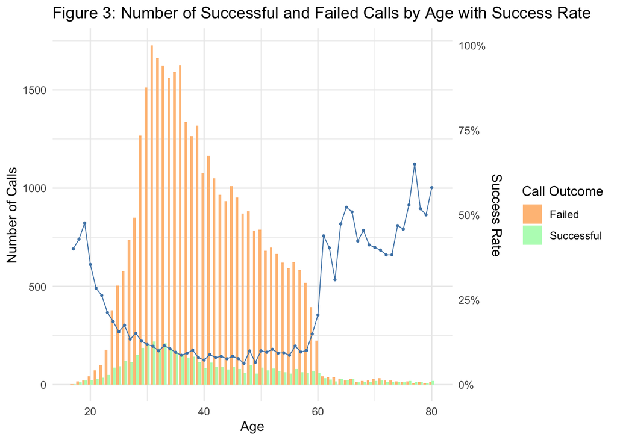

**Business Note:** We also wanted to take a look at how the success rate varies in relation to certain columns; in this case, Age. We show the portion of successes compared to failures, the success rate, and the number of observations for the range of ages. Although they have less calls when compared to 30-40 year olds, 18-25 year olds and 60-80 year olds have the highest success rate; this could prove insightful further into our analysis.

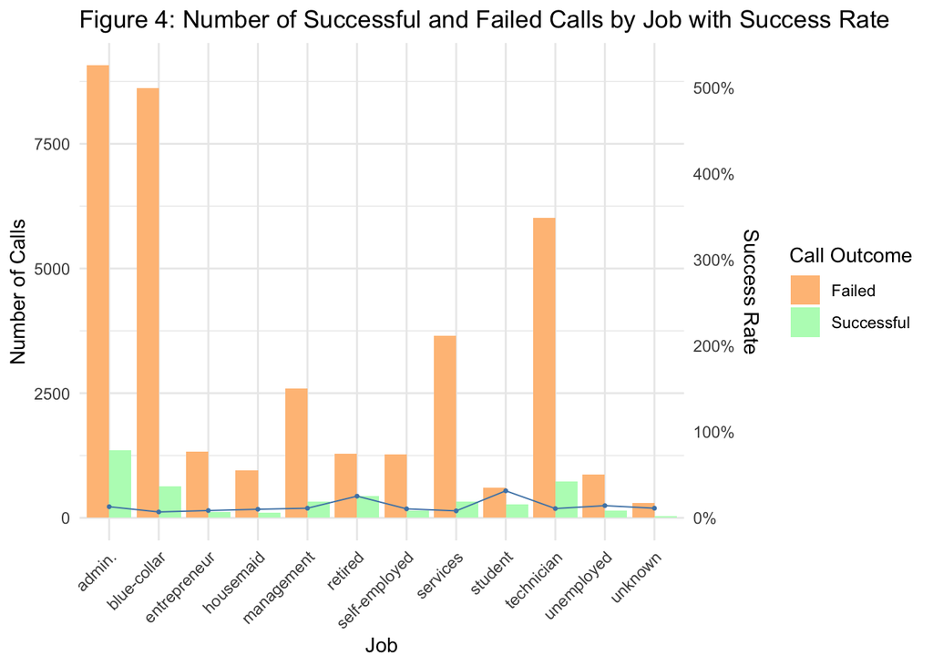

**Business Note:** Similar to figure 3, we now showcase successes, failures, and success rate by occupation type; we see that some occupation types, like admin, blue-collar, and technician, have a high number of calls, as well as that some occupation types like retired and student have higher success rates.

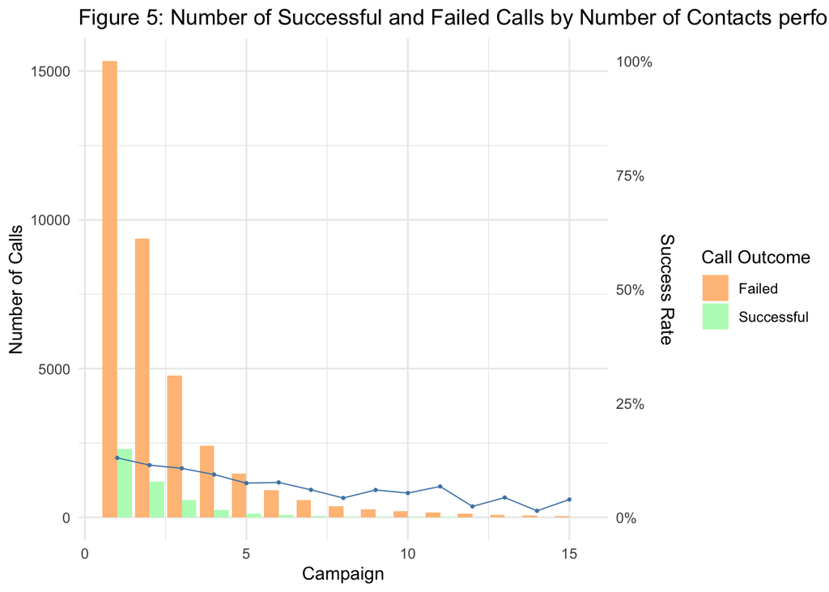

**Business Note:** Finally, we look at the three metrics from before, except now by the number of calls made to a client. We can see that the success rate dwindles upon repeated calls, something to note going forward.

**Business Note:** Upon inspecting our visuals, we have a few takeaways. We don’t need to increase the success rate by too much in order or the call center to break even. Additionally, the variables of Age, Job, and Campaign may be of significance when conducting our analysis; we see clear values for all three that increase the success rate. We will see if these findings come to fruition, or if they weren’t significant enough.

**Business Note:** With a comprehensive understanding of the current situation and the call center’s distance from break-even, we can begin exploring opportunities to leverage collected data to improve the success rate. In this section, we will focus on identifying distinct clusters of customers—groups of individuals who share similar characteristics or behaviors. The purpose of clustering is to, once these groups are defined, analyze the varying success rates across them. This approach enables associates to prioritize calls to clusters with higher success rates, optimizing efficiency and potentially boosting overall performance.

#### a. Defining the of clusters

The code below is getting the scaled data, deleting the prediction variable (as you don’t want it to be part of the variables used to build the clusters), and attributing that to a new data, `clustering_data`. Before constructing clusters, we first need to determine the optimal number of clusters. This can be done using several techniques, including Within-Cluster Sum of Squares (WSS), Gap Statistics, and Silhouette analysis—all of which are built-in functions in R.

PCA transforms the original variables into a smaller set of new, uncorrelated variables called principal components. Each principal component captures a certain amount of the total variance in the data. By selecting only the components that explain the majority of the variance (for example, 90-95%), we effectively condense the information from many variables into a few components. This reduces the dataset’s dimensionality, making computations faster and more memory-efficient without sacrificing significant information.

After applying PCA, we select a subset of components that explains 90% of the data’s variance. This reduced dataset, `clustering_data_pca`, was still computationally heavy, so we decided to sample 8,000 observations and from that apply the mentioned techniques (WSS, Gap Statistics, and Silhouette) to determine the optimal number of clusters.

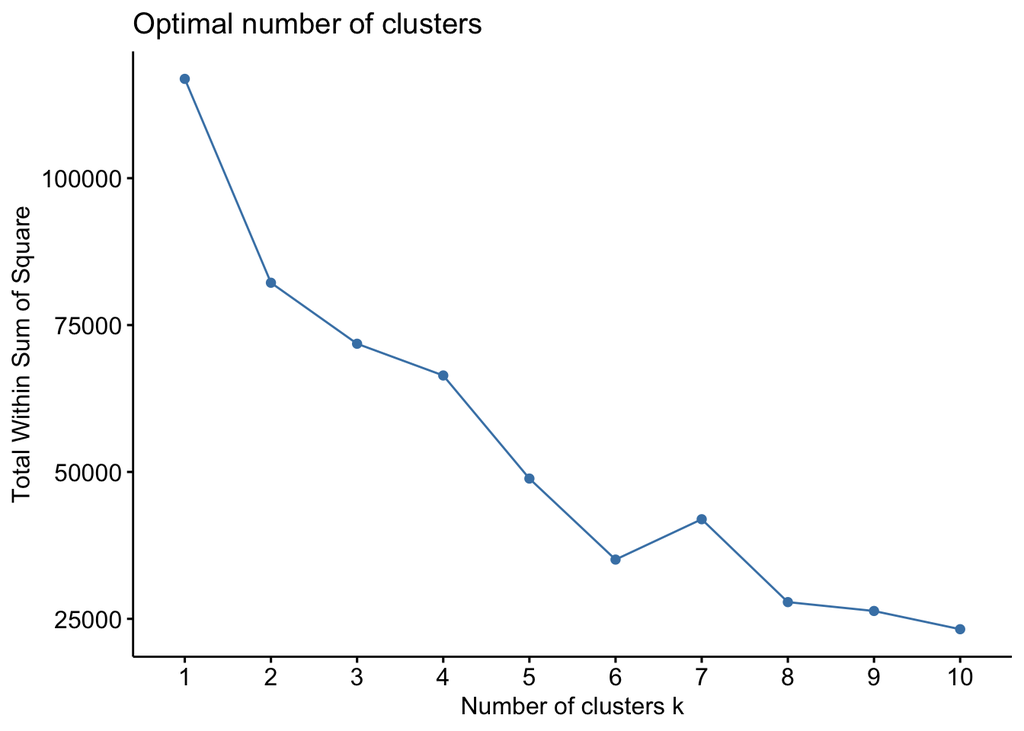

```r
y_col <- which(colnames(tele_data) == "y")

clustering_data <- scaled_data[,-y_col]
clustering_data <- as.data.frame(clustering_data)

numeric_data <- clustering_data[sapply(clustering_data, is.numeric)]
pca_result <- prcomp(numeric_data, scale. = TRUE)

explained_variance <- summary(pca_result)$importance[3,]
num_components <- which(cumsum(explained_variance) >= 0.90)[1]
clustering_data_pca <- pca_result$x[, 1:num_components]

set.seed(666)
clustering_data_pca_sample <- clustering_data_pca[sample(nrow(clustering_data_pca), 8000), ]

fviz_nbclust(clustering_data_pca_sample, kmeans, method = "wss")
```

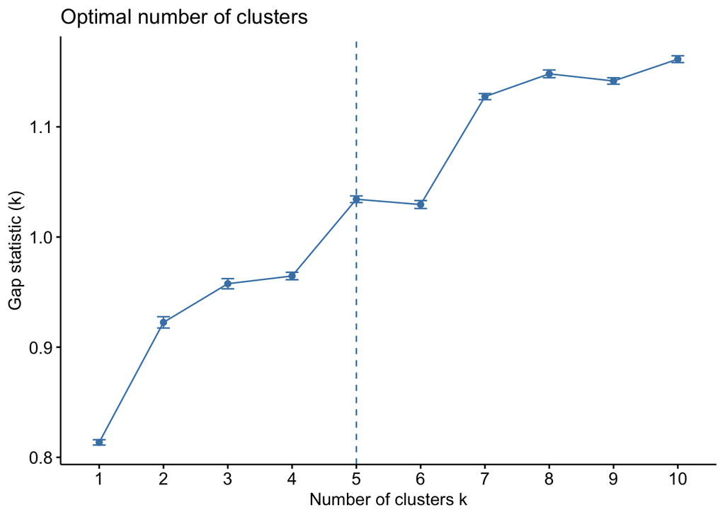

```r
fviz_nbclust(clustering_data_pca_sample, kmeans, method = "gap_stat")
```

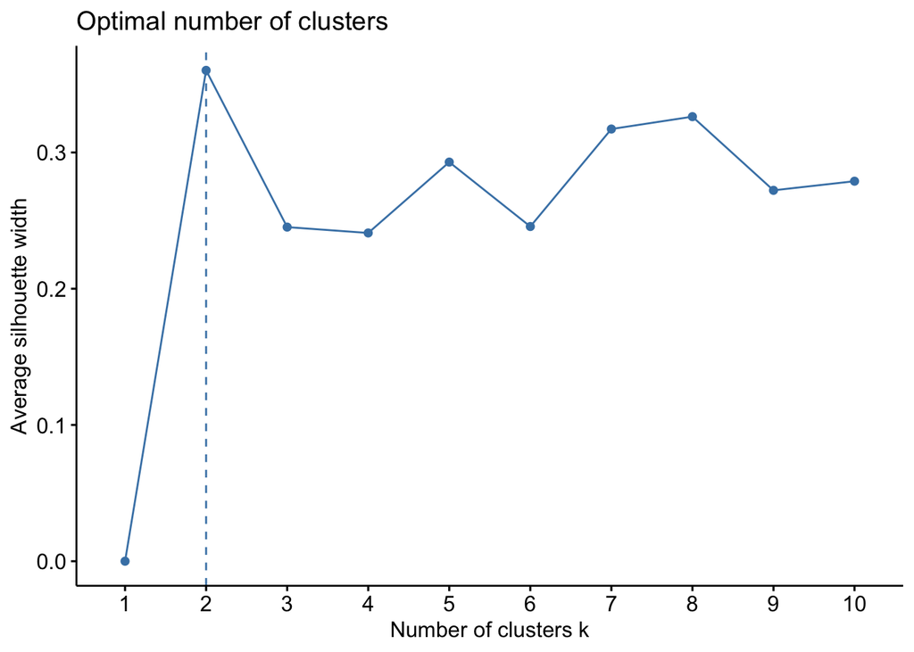

```r
fviz_nbclust(clustering_data_pca_sample, kmeans, method = "silhouette")
```

#### b. Building the clusters

After determining that we will use 6 clusters, we proceed with building them. The first few lines of code create the clusters using the k-means algorithm with k=6 and add a new column to `clustering_data` that specifies the assigned cluster for each row.

Next, we use the `fviz_cluster` function from the `factoextra` library to visualize the clusters. The first plot shows each data point within its respective cluster, while the second plot adds ellipses representing the normal distribution for each cluster, providing a clearer view of the cluster boundaries and dispersion.

Finally, we integrate the cluster assignments into the original `scaled_data`, which includes the target variable `y.` Using `tapply`, we calculate the mean value of `y` for each cluster. This calculation helps us understand the average outcome or behavior (as represented by `y`) within each cluster.

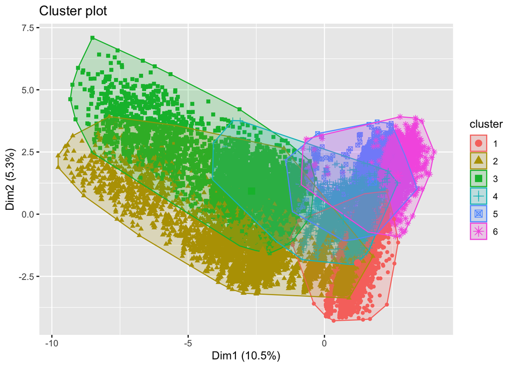

```r
#set.seed(123)
set.seed(666)
km <- kmeans(clustering_data, 6)
clustering_data$cluster <- km$cluster

fviz_cluster(km, data = clustering_data, geom = "point")
```

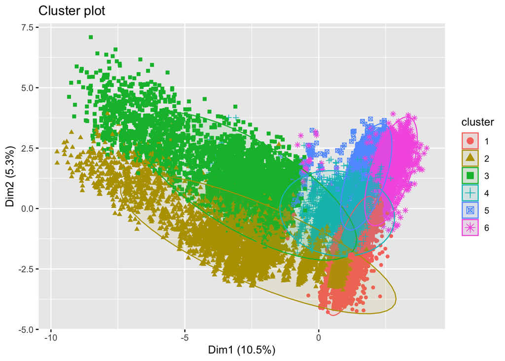

```r
fviz_cluster(km, data = clustering_data, geom = "point", ellipse = TRUE, ellipse.type = "norm", ellipse.level = 0.95, ellipse.alpha = 0.1)
```

```r
scaled_data$cluster <- km$cluster
tapply(scaled_data$y, scaled_data$cluster,mean)
```

```
##          1          2          3          4          5          6
## 0.06085526 0.20398293 0.23529412 0.05260030 0.03244275 0.04412099
```

Although the graphics appear to show overlapped clusters, it is important to remember this is a 2D graphic representing multi-dimensions, so they are not really overlapped. As for the `y` mean per cluster, it allows us to identify clusters with higher success rates (the ones with a higher means) and target them more effectively.

As seen by the output of the `tapply` function, cluster 3 is the one with the highest mean at 23.6%, followed by cluster 2 with a mean of 20.4%.

**Business Note:** Now that we have the clusters built, we can see which are likely to be the most profitable ones when looking at the clusters mean on failed (0) and successful (1) calls. Clusters **2** and **3** are likely to be the ones with the highest success rate. In the next segment we would look at how can we convert this concept into convincing financial figures.

#### c. Financial Performance/Opportunity

In this segment we come back to the initial calculations of Part A, of understanding the current scenario, but simulating would would have been the performance if the call center only called cluster 3, or called cluster 2 and 3. The other clusters have too low of a mean (lower than the current success rate) that it is not reasonable to call them as well.

```r
cluster_three <- scaled_data[scaled_data$cluster == 2, ]
c3_total_calls <- nrow(cluster_three)
c3_succesful_calls <- nrow(cluster_three[cluster_three$y==1, ])
c3_success_rate <- c3_succesful_calls/c3_total_calls

c3_revenue <- (c3_success_rate*c3_total_calls) * revenue_per_call

difference_success_rate <- (c3_success_rate - success_rate)*100
c3_total_cost <- (c3_total_calls*variable_cost_per_call) +
                  ((c3_total_calls/(avg_retention+(100*difference_success_rate)))*training_cost)

c3_gross_margin <- round((c3_revenue - c3_total_cost), 2)
```

```r
cluster_three_and_two <- scaled_data[scaled_data$cluster %in% c(2, 3), ]
c32_total_calls <- nrow(cluster_three_and_two)
c32_succesful_calls <- nrow(cluster_three_and_two[cluster_three_and_two$y==1, ])
c32_success_rate <- c32_succesful_calls/c32_total_calls

c32_revenue <- (c32_success_rate*c32_total_calls) * revenue_per_call

difference_success_rate2 <- (c32_success_rate - success_rate)*100
c32_total_cost <- (c32_total_calls*variable_cost_per_call) +
                  ((c32_total_calls/(avg_retention+(100*difference_success_rate2)))*training_cost)

c32_gross_margin <- round((c32_revenue - c32_total_cost), 2)
```

We could see that filtering of the calls made to the clusters with the highest success rates is a strategy that can boost the call centers performance. With a 10.8450709% increase in the success rate, making the call center not only break-even, but also profit.

Although at this point of the report it may seem like we have already reached a solution to the problem, there is a second approach that is worth trying and testing the performance, to in the end, choose the alternative in which the call center can profit the most

**Business Note:** In this segment of the report, our goal is to build 3 prediction models - a Logistic Regression, a K-Nearest Neighbors and a Neural Network - and see if by having a prediction of who are the potential successful calls, and targeting those, deliver a result as good as (or better than) the previous segment

#### a. Balancing the Data

Before proceeding, we need to remove the cluster column that was added to the scaled dataset in the previous segmentation phase. This column is irrelevant for the prediction model and could introduce noise or bias into the training process.

Before proceeding, we need to remove the cluster column that was added to the scaled dataset in the previous segmentation phase. This column is irrelevant for the prediction model and could introduce noise or bias into the training process.

Another key point to note is why data balancing is essential and how it impacts prediction models. When data is unbalanced, meaning one class is represented significantly more than another, prediction models tend to be biased towards the majority class. This can lead to poor generalization and unreliable predictions, especially for the minority class. By balancing the dataset, we ensure that our models have a fair representation of each class, enabling them to learn patterns more effectively from both classes and ultimately making the model more accurate and generalizable.

We are addressing the class imbalance issue at this stage, rather than during initial data cleaning, because balancing is a model-specific preprocessing step.

```r
scaled_data$cluster <- NULL

table(scaled_data$y)
```

```
##
##     0     1
## 36548  4640
```

```r
smote_data <- SMOTE(scaled_data[, -which(names(scaled_data) == "y")], scaled_data$y, K = 5, dup_size = 2)
balanced_data <- data.frame(smote_data$data)
names(balanced_data)[ncol(balanced_data)] <- "y"
balanced_data$y <- as.numeric(balanced_data$y)


smote_data_lr <- SMOTE(encoded_data[, -which(names(encoded_data) == "y")], encoded_data$y, K = 5, dup_size = 2)
balanced_data_lr <- data.frame(smote_data_lr$data)
names(balanced_data_lr)[ncol(balanced_data_lr)] <- "y"
balanced_data_lr$y <- as.numeric(balanced_data_lr$y)
```

To be more specific, our code applies Synthetic Minority Over-sampling Technique (SMOTE) to balance two datasets, `scaled_data` and `encoded_data`, by increasing instances of the minority class in the target variable `y`. For each dataset, it removes y from the features, applies SMOTE with 5 nearest neighbors and a duplication size of 2, and converts the result into a new balanced data frame. The target variable `y` is then renamed and converted to a numeric type in each balanced dataset, producing `balanced_data` and `balanced_data_lr` as the balanced versions of `scaled_data` and `encoded_data`.

#### b. Splitting the Data

Data splitting is essential in model training as it enables us to evaluate a model’s performance on data it hasn’t encountered before. By dividing our data into training and test sets, we create two separate groups: one for training the model (the training set) and another for evaluating its performance (the test set). This method helps us avoid overfitting, where the model could learn the training data too well and struggle to generalize to new, unseen data.

Separate data split for Network Models and Logistic Regression: We sample rows from the first balanced dataset to create training and test sets for the K-Nearest Neighbors (KNN), Artificial Neural Network (ANN), while for the Logistic Regression we are splitting the second balanced dataset, in which the data was not scaled.

```r
test_rate <- 0.2
#set.seed(666)
test_rows <- sample(1:nrow(balanced_data), test_rate*nrow(balanced_data))
train_data <- balanced_data[test_rows, ]
test_data <- balanced_data[-test_rows, ]

test_rows_lr <- sample(1:nrow(balanced_data_lr), test_rate*nrow(balanced_data_lr))
train_data_lr <- balanced_data_lr[test_rows_lr, ]
test_data_lr <- balanced_data_lr[-test_rows_lr, ]
```

#### c. Logistic Regression Model

In order to optimize our profits and only target customers who are predicted to buy our product, our team first developed a logistic regression. This model identifies relationships between various inputs and predicts the probability of an outcome. Furthermore, rather than pursuing a computationally-intensive process of building a giant model, and then a step one that simplifies it, this approach builds a simple model and then it performs a stepwise selection on the simple model. Stepwise selection is a method of refining a model by adding or removing predictors based on specific criteria.

As we want for the prediction to be binary, we create an `ifelse` in which every prediction below 0.25 is considered to be a failed call (0), and from 0.25 up a successful call (1).

```r
lr <- glm(y ~ ., data = train_data_lr, family = binomial)
stepwise_lr <- step(lr, direction = "both", trace = 0)

prediction_lr <- predict(stepwise_lr, test_data_lr, type = "response")
binary_prediction_lr <- ifelse(prediction_lr < .25, 0, 1)

confusionMatrix(as.factor(binary_prediction_lr),
                as.factor(test_data_lr$y),
                positive = "1")
```

```
## Confusion Matrix and Statistics
##
##           Reference
## Prediction     0     1
##          0 23942  3783
##          1  5313  7337
##
##                Accuracy : 0.7747
##                  95% CI : (0.7706, 0.7788)
##     No Information Rate : 0.7246
##     P-Value [Acc > NIR] : < 2.2e-16
##
##                   Kappa : 0.4586
##
##  Mcnemar's Test P-Value : < 2.2e-16
##
##             Sensitivity : 0.6598
##             Specificity : 0.8184
##          Pos Pred Value : 0.5800
##          Neg Pred Value : 0.8636
##              Prevalence : 0.2754
##          Detection Rate : 0.1817
##    Detection Prevalence : 0.3133
##       Balanced Accuracy : 0.7391
##
##        'Positive' Class : 1
##
```

In order to analyze the performance of this model, we ran a confusion matrix. The logistic regression model shows an accuracy of 77.47%, meaning it correctly classifies around 77% of cases. Its sensitivity (65.98%) indicates it identifies about 66% of actual positive cases, and the specificity is higher at 81.84%, showing that the model is better at identifying true negatives.

#### d. K-Nearest Neighbor Model

```r
y_col <- which(colnames(train_data) == "y")
prediction_knn <- knn(train = train_data[,-y_col],
                      test = test_data[,-y_col],
                      cl = train_data[,y_col],
                      k = 4)
summary(prediction_knn)
```

```
##     0     1
## 29525 10850
```

```r
confusionMatrix(as.factor(prediction_knn), as.factor(test_data$y), positive = "1")
```

```
## Confusion Matrix and Statistics
##
##           Reference
## Prediction     0     1
##          0 24854  4671
##          1  4299  6551
##
##                Accuracy : 0.7778
##                  95% CI : (0.7737, 0.7819)
##     No Information Rate : 0.7221
##     P-Value [Acc > NIR] : < 2.2e-16
##
##                   Kappa : 0.4408
##
##  Mcnemar's Test P-Value : 8.958e-05
##
##             Sensitivity : 0.5838
##             Specificity : 0.8525
##          Pos Pred Value : 0.6038
##          Neg Pred Value : 0.8418
##              Prevalence : 0.2779
##          Detection Rate : 0.1623
##    Detection Prevalence : 0.2687
##       Balanced Accuracy : 0.7182
##
##        'Positive' Class : 1
##
```

#### e. Neural Network Model

For our third and final prediction model, we built an Artificial Neural Network (ANN). This model generates predictions by recognizing patterns within complex data. An ANN consists of individual units called neurons, which function similarly to linear regressions, connected through multiple layers. The connections between neurons have weights, which are adjusted through a process called backpropagation. During backpropagation, the network iteratively updates these weights to minimize prediction errors, allowing the model to learn and improve its accuracy over time.

```r
ann <- neuralnet(y ~ ., data = train_data, hidden = c(1, 1), stepmax = 1e6, lifesign = "none", learningrate = 0.1)
plot(ann)

prediction_nn <- predict(ann, newdata = test_data)
summary(prediction_nn)
```

```
##        V1
##  Min.   :0.08359
##  1st Qu.:0.11286
##  Median :0.15133
##  Mean   :0.27171
##  3rd Qu.:0.33255
##  Max.   :0.76721
```

```r
binary_prediction_nn <- ifelse(prediction_nn > 0.2, 1, 0)
confusionMatrix(as.factor(binary_prediction_nn),
                as.factor(test_data$y),
                positive = "1")
```

```
## Confusion Matrix and Statistics
##
##           Reference
## Prediction     0     1
##          0 22853  3447
##          1  6300  7775
##
##                Accuracy : 0.7586
##                  95% CI : (0.7544, 0.7628)
##     No Information Rate : 0.7221
##     P-Value [Acc > NIR] : < 2.2e-16
##
##                   Kappa : 0.4422
##
##  Mcnemar's Test P-Value : < 2.2e-16
##
##             Sensitivity : 0.6928
##             Specificity : 0.7839
##          Pos Pred Value : 0.5524
##          Neg Pred Value : 0.8689
##              Prevalence : 0.2779
##          Detection Rate : 0.1926
##    Detection Prevalence : 0.3486
##       Balanced Accuracy : 0.7384
##
##        'Positive' Class : 1
##
```

#### f. Combined Predictions

```r
binary_prediction_lr <- as.factor(binary_prediction_lr)
prediction_knn <- as.factor(prediction_knn)
binary_prediction_nn <- as.factor(binary_prediction_nn)

# Apply weighted voting (example: logistic gets more weight)
combined_pred <- as.factor(ifelse(rowSums(cbind((binary_prediction_lr == "1"), (prediction_knn == "1"), (binary_prediction_nn == "1")*2)) >= 2, "1", "0"))

combined_confusion_matrix <- confusionMatrix(combined_pred, as.factor(test_data$y), positive = "1")
combined_confusion_matrix
```

```
## Confusion Matrix and Statistics
##
##           Reference
## Prediction     0     1
##          0 22707  2942
##          1  6446  8280
##
##                Accuracy : 0.7675
##                  95% CI : (0.7633, 0.7716)
##     No Information Rate : 0.7221
##     P-Value [Acc > NIR] : < 2.2e-16
##
##                   Kappa : 0.4715
##
##  Mcnemar's Test P-Value : < 2.2e-16
##
##             Sensitivity : 0.7378
##             Specificity : 0.7789
##          Pos Pred Value : 0.5623
##          Neg Pred Value : 0.8853
##              Prevalence : 0.2779
##          Detection Rate : 0.2051
##    Detection Prevalence : 0.3647
##       Balanced Accuracy : 0.7584
##
##        'Positive' Class : 1
##
```

The combined model achieved an accuracy of 76.75%, meaning it correctly classified about 77% of cases. The sensitivity (73.78%) indicates that it successfully identifies around 74% of actual positive cases, while specificity (77.89%) shows a similar performance in correctly identifying negatives. Overall, this ensemble model demonstrates a solid performance across both positive and negative cases.

An important thing to notice is that, although the double weight on the ANN will decrease the overall predictions success rate in the next step (decreases from a 61% to a 56%), this model captures more clients, and make more calls, making it more profitable. The trade-off is that by decreasing a bit the success rate, we will increase the total amount of calls to be made, which also increases the gross margin.

#### g. Financial Performance/Opportunity

**Business Note:** Now, with all the models built and a combined prediction that leverages each model’s strength, we can measure how successful would be to implement this method for the Call Center. We will be running similar calculations than for the clustering segment, to compare the performances.

```r
true_positives <- combined_confusion_matrix$table[2, 2]
prediction_false_positives <- combined_confusion_matrix$table[2, 1]
total_positives <- prediction_false_positives+true_positives

prediction_sucess_rate <- (true_positives)/total_positives
prediction_percentage_of_total_calls <- total_positives/nrow(test_data)
prediction_total_calls <- round((prediction_percentage_of_total_calls * total_calls),0)
prediction_successful_calls <- round((prediction_sucess_rate*prediction_total_calls),0)

predition_revenue <- prediction_total_calls * revenue_per_call

difference_success_rate3 <- (prediction_sucess_rate - success_rate)*100
prediction_total_costs <- (prediction_total_calls*variable_cost_per_call) +
                  ((prediction_total_calls/(avg_retention+(100*difference_success_rate3)))*training_cost)

prediction_gross_margin <- round((predition_revenue - prediction_total_costs), 2)
```

### Conclusion:

After thoroughly analyzing the problem and evaluating two potential strategies for enhancing the Call Center’s performance—customer clustering and predictive modeling—it is clear that both approaches offer significant improvements given the current business context. However, the gross margin associated with the predictive modeling strategy is notably higher. Additionally, there is substantial room for further refinement within the predictive models, including optimizing feature selection, exploring more complex models, implementing cross-validation, and employing advanced ensemble methods. These improvements could lead to even more substantial financial gains.

In light of these insights, the final recommendation for Susan and her team is to prioritize the predictive modeling approach in the upcoming period. By using these models to identify which clients to contact, the team can increase the success rate, lower operational costs, and ultimately enhance the firm’s profitability.